# EXPLORATORY DATA ANALYSIS : RETAIL

Objectives: To Perform Exploratory Data Analysis on dataset SampleSuperstore. As a business manager, try to find out the weak areas where you can work to make more profit. What all business problems you can derive by exploring the data.

Author: Irshad

## Installing and loading necessary libraries

```r
install.packages("tidyverse")
library(tidyverse)
install.packages("ggplot2")
library(ggplot2)
install.packages("skimr")
library(skimr)
install.packages("janitor")
library(janitor)
install.packages("dplyr")
library(dplyr)
```

## Importing the dataset

```r
Superstore <- read_csv("SampleSuperstore.csv") #load the data
```

## Dataset features

```r
head(Superstore) ## Prints the top 6 rows of data
```

[output not shown]

## Information about the dataset

```r
skim_without_charts(Superstore)
```

Data summary

| Name | Superstore |
| --- | --- |
| Number of rows | 9994 |
| Number of columns | 13 |
| _______________________ |  |
| Column type frequency: |  |
| character | 8 |
| numeric | 5 |
| ________________________ |  |
| Group variables | None |

**Variable type: character**

| skim_variable | n_missing | complete_rate | min | max | empty | n_unique | whitespace |
| --- | --- | --- | --- | --- | --- | --- | --- |
| Shipmode | 0 | 1 | 8 | 14 | 0 | 4 | 0 |
| Segment | 0 | 1 | 8 | 11 | 0 | 3 | 0 |
| Country | 0 | 1 | 13 | 13 | 0 | 1 | 0 |
| City | 0 | 1 | 4 | 17 | 0 | 531 | 0 |
| State | 0 | 1 | 4 | 20 | 0 | 49 | 0 |
| Region | 0 | 1 | 4 | 7 | 0 | 4 | 0 |
| Category | 0 | 1 | 9 | 15 | 0 | 3 | 0 |
| Subcategory | 0 | 1 | 3 | 11 | 0 | 17 | 0 |

**Variable type: numeric**

| skim_variable | n_missing | complete_rate | mean | sd | p0 | p25 | p50 | p75 | p100 |
| --- | --- | --- | --- | --- | --- | --- | --- | --- | --- |
| Postal Code | 0 | 1 | 55190.38 | 32063.69 | 1040.00 | 23223.00 | 56430.50 | 90008.00 | 99301.00 |
| Sales | 0 | 1 | 229.86 | 623.25 | 0.44 | 17.28 | 54.49 | 209.94 | 22638.48 |
| Quantity | 0 | 1 | 3.79 | 2.23 | 1.00 | 2.00 | 3.00 | 5.00 | 14.00 |
| Discount | 0 | 1 | 0.16 | 0.21 | 0.00 | 0.00 | 0.20 | 0.20 | 0.80 |
| Profit | 0 | 1 | 28.66 | 234.26 | -6599.98 | 1.73 | 8.67 | 29.36 | 8399.98 |

```r
glimpse(Superstore)
```

```
## Rows: 9,994
## Columns: 13
## $ Shipmode      <chr> "Second Class", "Second Class", "Second Class", "Standar…
## $ Segment       <chr> "Consumer", "Consumer", "Corporate", "Consumer", "Consum…
## $ Country       <chr> "United States", "United States", "United States", "Unit…
## $ City          <chr> "Henderson", "Henderson", "Los Angeles", "Fort Lauderdal…
## $ State         <chr> "Kentucky", "Kentucky", "California", "Florida", "Florid…
## $ `Postal Code` <dbl> 42420, 42420, 90036, 33311, 33311, 90032, 90032, 90032, …
## $ Region        <chr> "South", "South", "West", "South", "South", "West", "Wes…
## $ Category      <chr> "Furniture", "Furniture", "Office Supplies", "Furniture"…
## $ Subcategory   <chr> "Bookcases", "Chairs", "Labels", "Tables", "Storage", "F…
## $ Sales         <dbl> 261.9600, 731.9400, 14.6200, 957.5775, 22.3680, 48.8600,…
## $ Quantity      <dbl> 2, 3, 2, 5, 2, 7, 4, 6, 3, 5, 9, 4, 3, 3, 5, 3, 6, 2, 2,…
## $ Discount      <dbl> 0.00, 0.00, 0.00, 0.45, 0.20, 0.00, 0.00, 0.20, 0.20, 0.…
## $ Profit        <dbl> 41.9136, 219.5820, 6.8714, -383.0310, 2.5164, 14.1694, 1…
```

```r
colnames(Superstore) ##Displays the column names
```

```
##  [1] "Shipmode"    "Segment"     "Country"     "City"        "State"
##  [6] "Postal Code" "Region"      "Category"    "Subcategory" "Sales"
## [11] "Quantity"    "Discount"    "Profit"
```

```r
sum(is_null(Superstore)) ## Checking for null values
```

```
## [1] 0
```

#### Checking if there are any duplicate rows

```r
sum(duplicated(Superstore))
```

```
## [1] 17
```

```r
Superstore <- unique(Superstore) ##Removing Duplicate
```

```r
str(Superstore) ##Duplicates removed
```

```
## tibble[,13] [9,977 × 13] (S3: tbl_df/tbl/data.frame)
##  $ Shipmode   : chr [1:9977] "Second Class" "Second Class" "Second Class" "Standard Class" ...
##  $ Segment    : chr [1:9977] "Consumer" "Consumer" "Corporate" "Consumer" ...
##  $ Country    : chr [1:9977] "United States" "United States" "United States" "United States" ...
##  $ City       : chr [1:9977] "Henderson" "Henderson" "Los Angeles" "Fort Lauderdale" ...
##  $ State      : chr [1:9977] "Kentucky" "Kentucky" "California" "Florida" ...
##  $ Postal Code: num [1:9977] 42420 42420 90036 33311 33311 ...
##  $ Region     : chr [1:9977] "South" "South" "West" "South" ...
##  $ Category   : chr [1:9977] "Furniture" "Furniture" "Office Supplies" "Furniture" ...
##  $ Subcategory: chr [1:9977] "Bookcases" "Chairs" "Labels" "Tables" ...
##  $ Sales      : num [1:9977] 262 731.9 14.6 957.6 22.4 ...
##  $ Quantity   : num [1:9977] 2 3 2 5 2 7 4 6 3 5 ...
##  $ Discount   : num [1:9977] 0 0 0 0.45 0.2 0 0 0.2 0.2 0 ...
##  $ Profit     : num [1:9977] 41.91 219.58 6.87 -383.03 2.52 ...
```

## Checking for Outliers

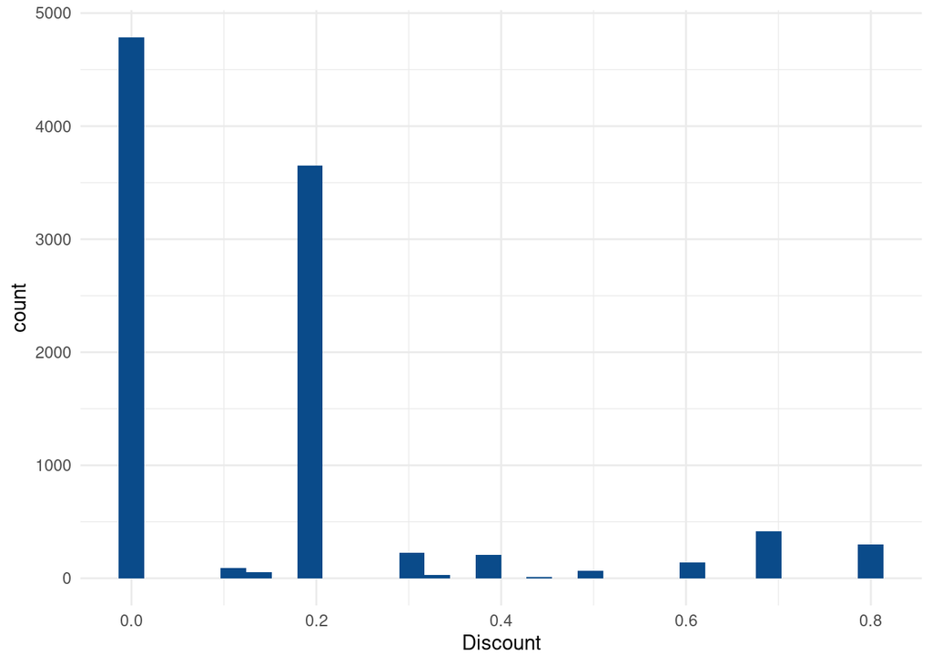

```r
ggplot(Superstore) +
  aes(x = Discount) +
  geom_histogram(bins = 30L, fill = "#0a4b8a") +
  theme_minimal()
```

```r
Superstore <- filter(Superstore, Discount > 0.45) ##filtering outliers
```

```r
head(Superstore$Discount) #filtered outliers
```

```
## [1] 0.8 0.8 0.5 0.7 0.7 0.6
```

## Data visualization

### * Analysing Shipmode

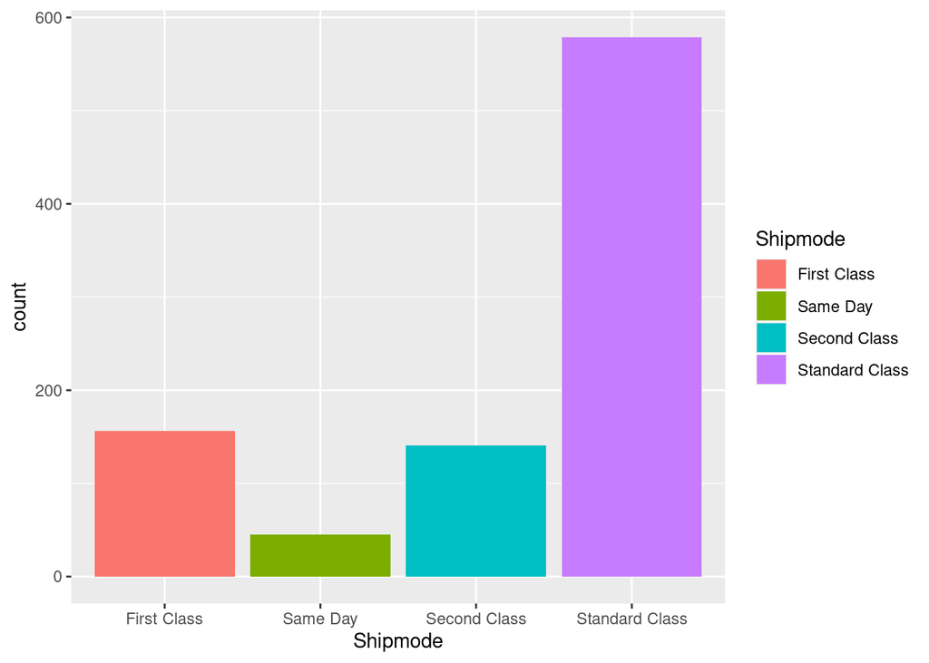

```r
ggplot(Superstore, aes(Shipmode)) + geom_bar(aes(fill = Shipmode))
```

### Analysis 1

#### we can find out that standard class ship mode is preferred more than the other ship modes are available.

## * Analysing Segment

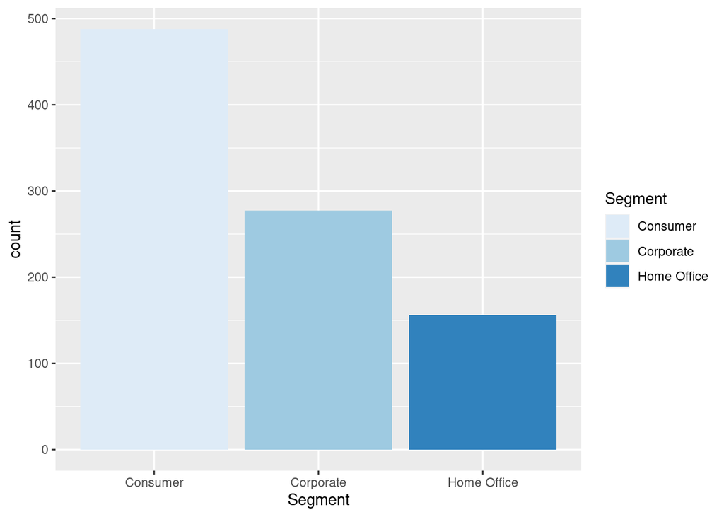

```r
ggplot(Superstore, aes(Segment )) + geom_bar(aes(fill = Segment )) +  scale_fill_brewer(palette = "Blues")
```

### Analysis 2

#### Consumer has the highest count than corporate and home office.

## * Analysing Category

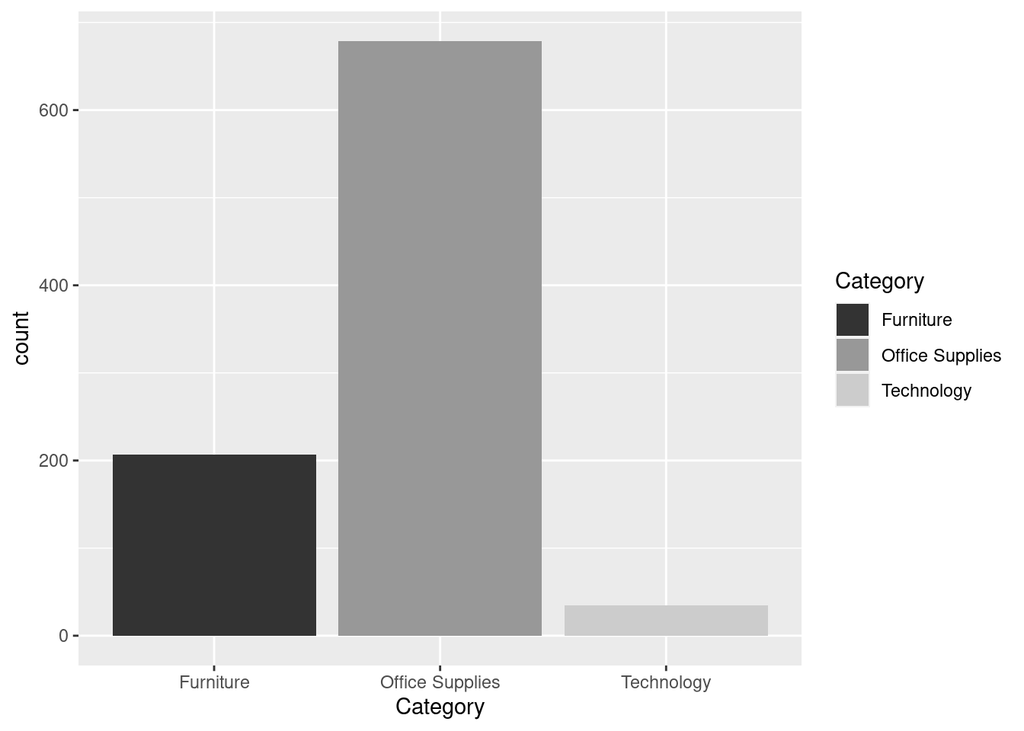

```r
ggplot(Superstore, aes(Category)) + geom_bar(aes(fill = Category)) + scale_fill_grey(
start = 0.2, end = 0.8,
na.value = "red")
```

### Analysis 3

#### Office Supplies Category has the highest count.

## * Analysing Region

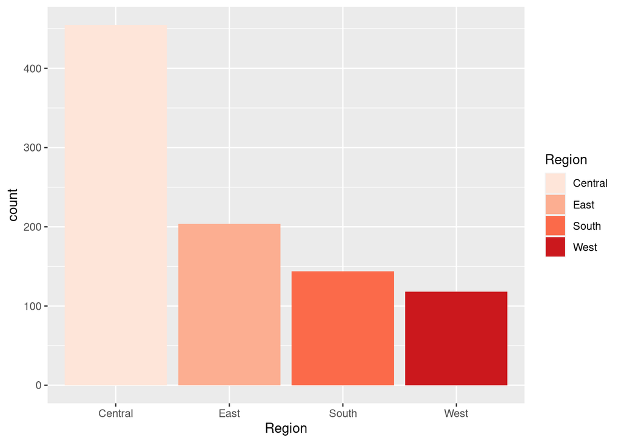

```r
ggplot(Superstore, aes(Region)) + geom_bar(aes(fill = Region)) + scale_fill_brewer(palette = "Reds")
```

## * Analysing Category and Sub-Category

[figure not shown]

```r
ggplot(data=Superstore) + geom_bar(mapping = aes(x=Category , fill=Subcategory)) + facet_wrap(~ Subcategory) +  theme(axis.text.x = element_text(angle = 30))
```

### Analysis 5

#### * Furniture which consists of 4 subcategories items Bookcases, Chairs, Tables, Furnishings

#### * Office Supplies category consist 9 sub-categories Labels, Storage, Art, Binders, Appliances, Paper, Envelopes, Fasteners, Supplies

#### * Technology involves 4 subcategories, those are Phones, Accessories, Machines, Copiers.

## * Analysing Profit, Discount and Sales

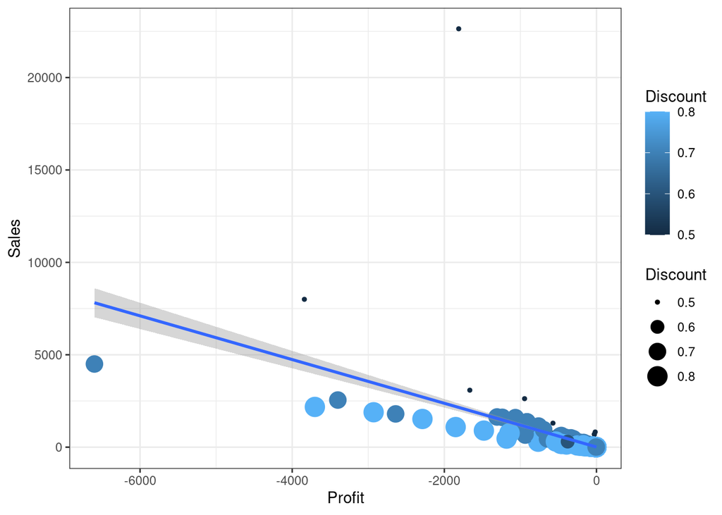

```r
ggplot(Superstore, aes(Profit , Sales)) +
 geom_point(aes(color = Discount , size=Discount)) +
 geom_smooth(method ="lm") +
 coord_cartesian() +
 scale_color_gradient() +
 theme_bw()
```

## * sales vs profit

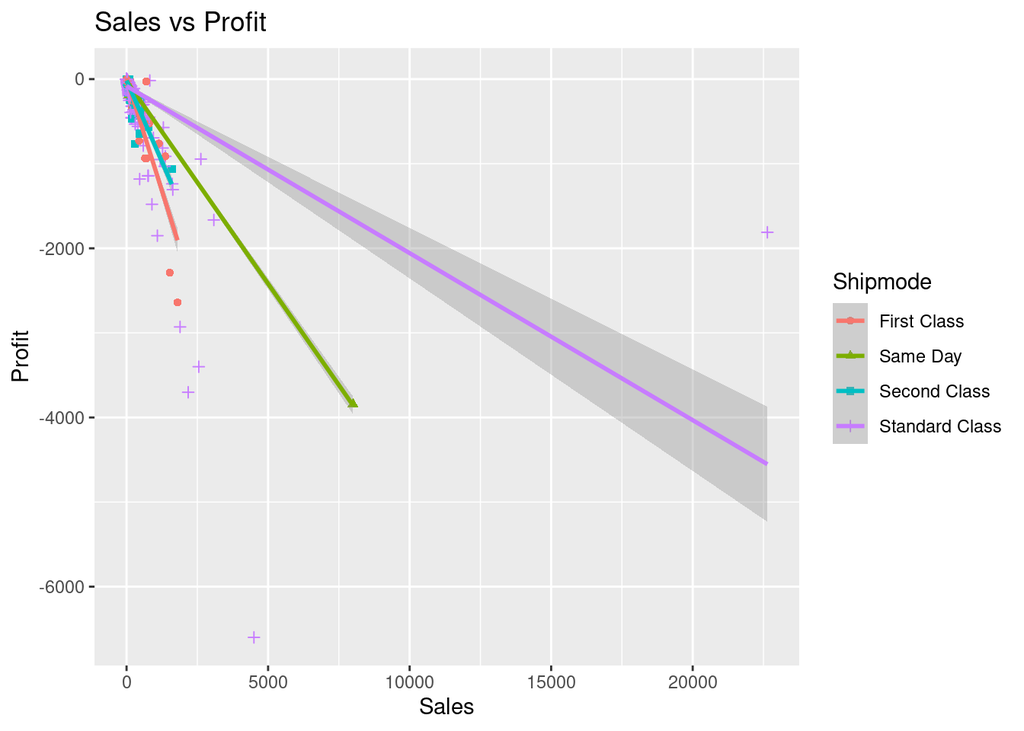

```r
ggplot(data=Superstore, aes(x=Sales,y=Profit,col= Shipmode, shape=Shipmode))+ geom_point()+geom_smooth(method ="lm")+labs(title="Sales vs Profit")
```

### Analysis 6

#### More profit/Loss from Standard class.

## * Sales vs Discount

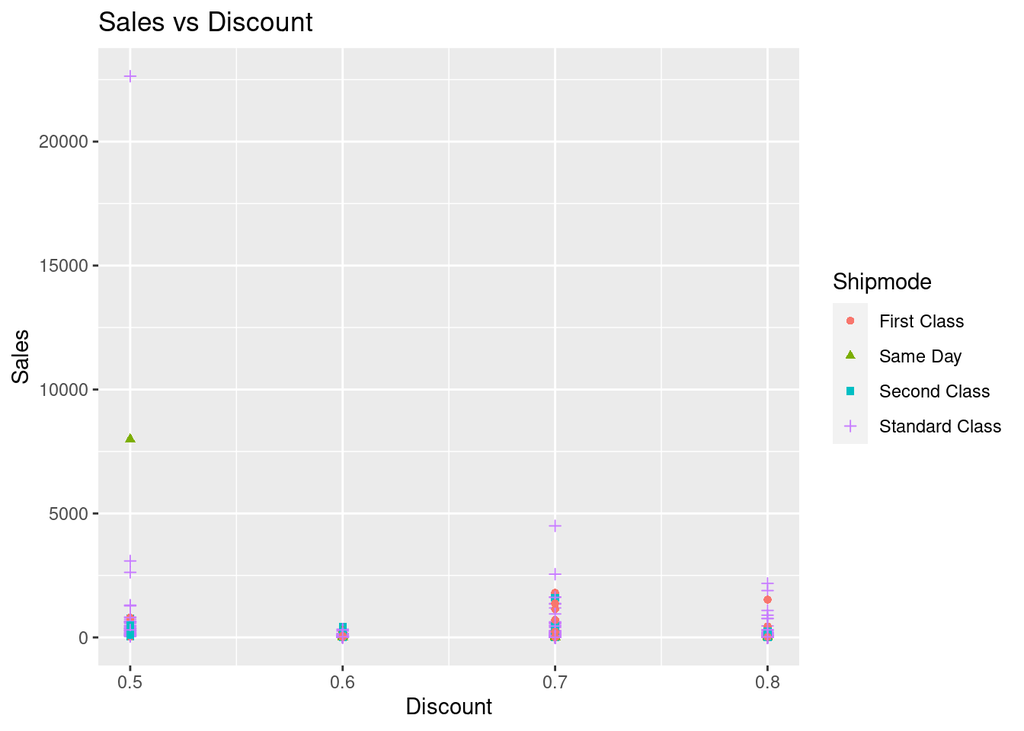

```r
ggplot() + geom_point(data=Superstore, aes(x=Discount,y=Sales,col= Shipmode, shape=Shipmode))+labs(title="Sales vs Discount")
```

### Analysis 7

#### Discount attracts mostly the Standard class ,Same day receive least Discount

## * Category vs Discount

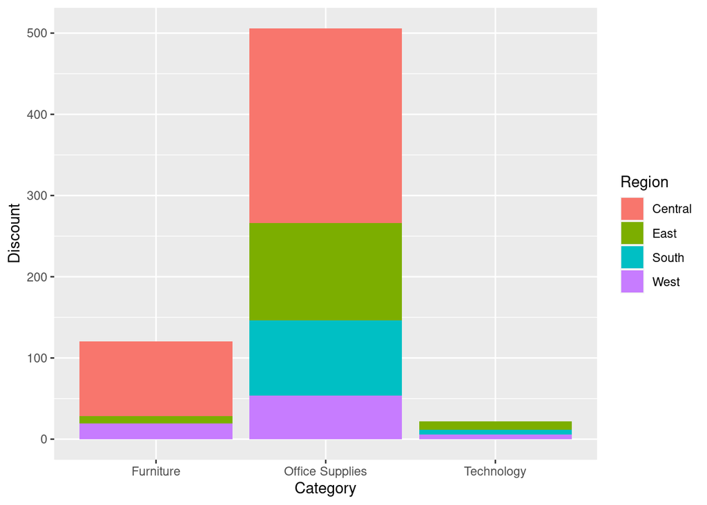

```r
ggplot() + geom_bar(data=Superstore, aes(x=Category,y=Discount,fill= Region),stat = "identity")
```

### Analysis 8

### office suppliers gets more Discount

## * Profit and Discount trade off in the different category

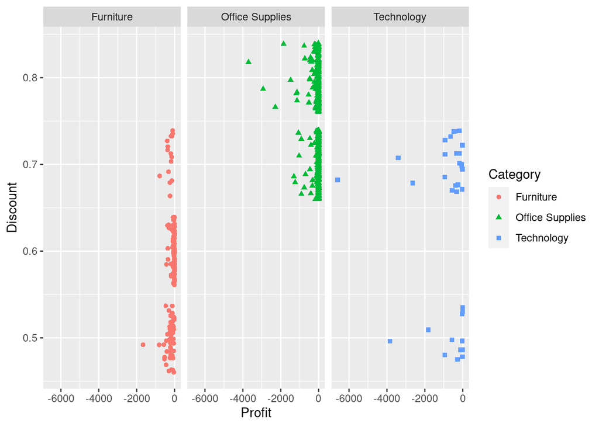

```r
ggplot(Superstore, aes(Profit ,Discount )) +   geom_jitter(aes(shape = Category, color = Category)) + facet_grid(~ Category)
```

### Analysis 9

#### As discount is increased 0.5 or more losses are faced in all categories product.

## * Sales and discount of Product effect in the different category product.

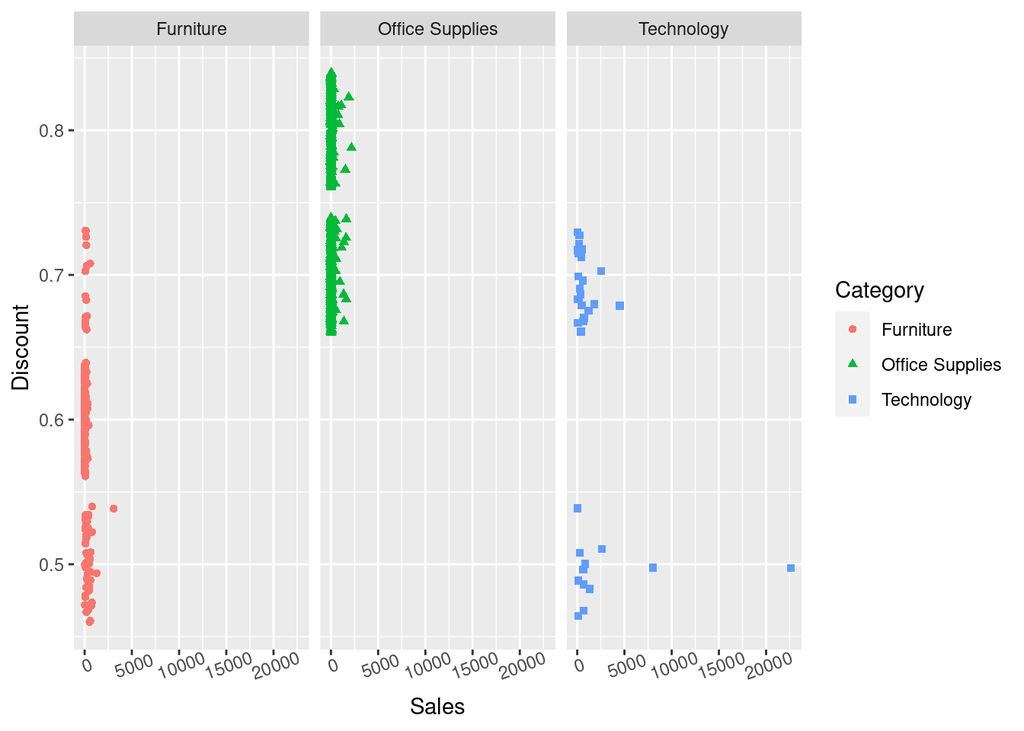

```r
ggplot(Superstore, aes(Sales ,Discount )) +   geom_jitter(aes(shape = Category, color = Category))  +facet_wrap(~ Category)+ theme(axis.text.x = element_text(angle = 20))
```

## Conclusion

#### * If Same day shipment receives more discounts then can trigger more sales/Profit.